## Curso R. UPO-EBD, Nov 2013. Pedro Jordano.

Here we include the `R` code used in the practices related to diversity analysis.

# Diversity

First, let us load the packages that will be used in this script.

```r
require(MASS)
require(datasets)
require(ade4)
require(BiodiversityR)
require(vegan)
require(FD)
```

Now let's start with the estimation of several diversity indexes. First, the Shannon–Weaver \(H'\): \(H'= -\sum p_i log p_i\)

The Simpson's index: \(D_2= 1-\sum {p_i}^2\)

and Fisher's alpha (\(\alpha\) parameter for the logseries distribution)

```r
data(BCI)  # We load the BCI plot dataset
H <- diversity(BCI)  # H'
H <- diversity(BCI, index = "simpson")  # Simpson's
J <- H/log(specnumber(BCI))  # Evenness
alpha <- fisher.alpha(BCI)  # Fisher's alpha
```

Renyi diversities of order \(a\): \(H_a = \frac{1}{(1−a)} log(\sum {p_i}^a)\) ; where \(a\) is a scale parameter.

The corresponding Hill's numbers are: \(Na=exp(Ha)\)

The diversity indexes used most often are special cases of the Hill's numbers: \(N0 = S\) ; \(N1 = exp(H')\); \(N2 = D2\) (inverse of Simpson's index): \(1/\sum {p_i}^2\); and \(N\infty = 1/(max p_i)\)

The corresponding Renyi diversities are: \(H_0 = log(S)\); \(H_1 = H'\); \(H_2 = -log(\sum {pi}^2)\); and \(H_{\infty}= − log(max p_i)\)

A way to compare diversities is to examine the Renyi indexes for a range of \(a\) values, typically \(0, 1, 2, 4 … \infty\).

We select 9 BCI subplots to estimate their diversity:

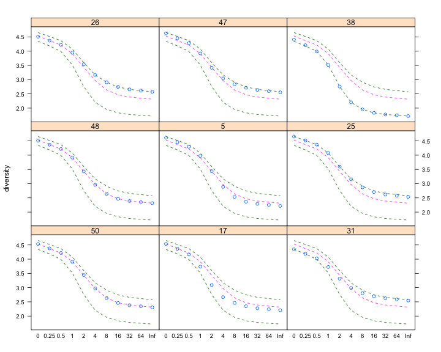

```r
data(BCI)
i <- sample(nrow(BCI), 9)
mod <- renyi(BCI[i, ])
plot(mod)
```

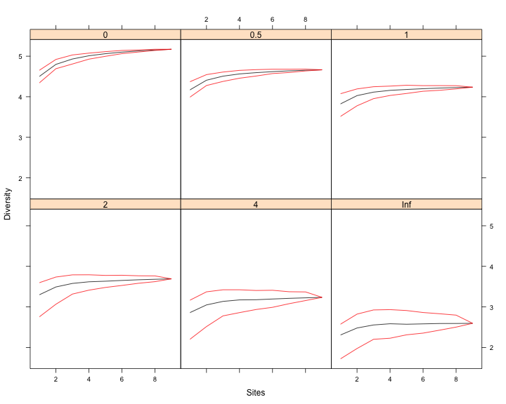

```r
mod <- renyiaccum(BCI[i, ])
plot(mod, as.table = TRUE, col = c(1, 2, 2))
```

## Rarefaction

Expected species richness in random subsamples- of a given size- of the community.

```r
rowSums(BCI)
```

```
##   1   2   3   4   5   6   7   8   9  10  11  12  13  14  15  16  17  18
## 448 435 463 508 505 412 416 431 409 483 401 366 409 438 462 437 381 347
##  19  20  21  22  23  24  25  26  27  28  29  30  31  32  33  34  35  36
## 433 429 408 418 340 392 442 407 417 387 364 475 421 459 436 447 601 430
##  37  38  39  40  41  42  43  44  45  46  47  48  49  50
## 435 447 424 489 402 414 407 409 444 430 425 415 427 432
```

```r
specnumber(BCI)  # Esta S relacionado con Nind?
```

```
##   1   2   3   4   5   6   7   8   9  10  11  12  13  14  15  16  17  18
##  93  84  90  94 101  85  82  88  90  94  87  84  93  98  93  93  93  89
##  19  20  21  22  23  24  25  26  27  28  29  30  31  32  33  34  35  36
## 109 100  99  91  99  95 105  91  99  85  86  97  77  88  86  92  83  92
##  37  38  39  40  41  42  43  44  45  46  47  48  49  50
##  88  82  84  80 102  87  86  81  81  86 102  91  91  93
```

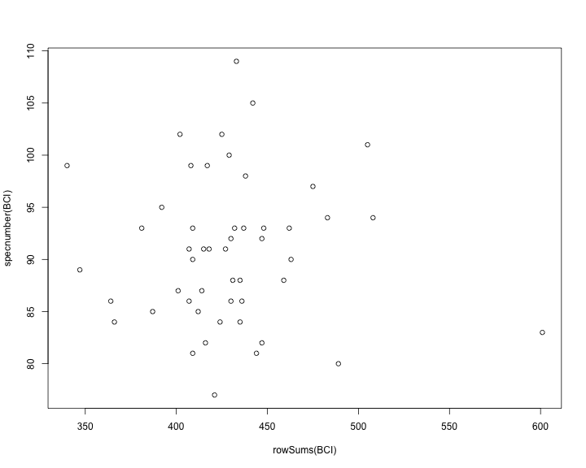

```r
plot(rowSums(BCI), specnumber(BCI))
```

```r
Srar <- rarefy(BCI, min(rowSums(BCI)))
```

### Species accumulation and asymptotic estimators

```r
sac <- specaccum(BCI)
```

```r
plot(sac, ci.type = "polygon", ci.col = "yellow")
```

[figure not shown]

```r
sac2 <- specaccum(BCI, "random")
plot(sac, ci.type = "poly", col = "blue", lwd = 2, ci.lty = 0, ci.col = "lightblue")
boxplot(sac2, col = "yellow", add = TRUE, pch = "+")
```

[figure not shown]

```r
sac2
```

```
## Species Accumulation Curve
## Accumulation method: random, with 100 permutations
## Call: specaccum(comm = BCI, method = "random")
##
##
## Sites     1.000   2.000   3.000   4.000   5.000   6.000   7.000   8.000
## Richness 91.990 121.760 139.560 150.370 158.910 166.210 171.380 175.580
## sd        7.333   7.292   7.104   6.917   6.095   5.433   5.488   5.476
##
## Sites      9.000  10.000  11.000  12.000  13.000  14.000  15.000  16.000
## Richness 179.860 183.000 186.010 188.410 190.630 192.730 194.550 196.250
## sd         5.184   5.055   5.066   4.695   4.823   4.519   4.516   4.596
##
## Sites     17.000  18.00  19.000  20.000  21.000  22.000  23.000  24.000
## Richness 197.660 199.18 201.010 202.530 203.830 204.980 206.020 206.980
## sd         4.363   4.12   4.079   3.839   4.043   4.095   4.005   3.929
##
## Sites     25.000  26.000  27.000  28.000  29.000  30.000  31.000  32.000
## Richness 207.930 208.910 210.070 211.150 211.930 212.900 213.860 214.540
## sd         3.973   3.859   3.809   3.557   3.517   3.362   3.339   3.233
##
## Sites     33.000  34.000  35.000  36.000  37.00  38.000  39.000  40.000
## Richness 215.320 216.050 216.710 217.230 217.90 218.570 219.210 219.930
## sd         3.139   3.076   3.013   2.909   2.74   2.716   2.698   2.442
##
## Sites     41.000  42.000  43.000  44.000  45.0  46.00  47.000  48.000
## Richness 220.560 221.080 221.570 222.170 222.6 223.27 223.760 224.170
## sd         2.306   2.087   1.876   1.712   1.7   1.42   1.173   1.006
##
## Sites     49.0000  50
## Richness 224.5800 225
## sd         0.6843   0
```

Another way, using the `BiodiversityR` package.

```r
BCI$site.totals <- apply(BCI, 1, sum)  # Totals by plot
Accum.1 <- accumresult(BCI, y = BCI, scale = "site.totals", method = "exact")
Accum.1
```

```
## Species Accumulation Curve
## Accumulation method: exact
## Call: specaccum(comm = x, method = method, permutations = permutations,      conditioned = conditioned, gamma = gamma)
##
##
## Sites    429.140 858.280 1287.420 1716.560 2145.700 2574.840 3003.980
## Richness  91.780 122.610  140.046  151.712  160.236  166.831  172.142
## sd         6.935   7.193    7.002    6.636    6.248    5.895    5.591
##
## Sites    3433.120 3862.260 4291.40 4720.540 5149.680 5578.820 6007.96
## Richness  176.553  180.306  183.56  186.429  188.991  191.306  193.42
## sd          5.337    5.126    4.95    4.803    4.677    4.567    4.47
##
## Sites    6437.100 6866.2 7295.380 7724.520 8153.660 8582.8 9011.940
## Richness  195.355  197.1  198.819  200.381  201.849  203.2  204.543
## sd          4.382    4.3    4.222    4.147    4.073    4.0    3.927
##
## Sites    9441.080 9870.220 10299.360 10728.500 11157.640 11586.780
## Richness  205.785  206.967   208.094   209.170   210.199   211.184
## sd          3.853    3.779     3.703     3.627     3.549     3.469
##
## Sites    12015.920 12445.060 12874.200 13303.340 13732.480 14161.620
## Richness   212.130   213.037   213.909   214.747   215.554   216.331
## sd           3.388     3.306     3.221     3.135     3.047     2.957
##
## Sites    14590.760 15019.900 15449.040 15878.180 16307.320 16736.460
## Richness   217.079   217.800   218.495   219.165   219.811   220.434
## sd           2.864     2.769     2.671     2.571     2.466     2.358
##
## Sites    17165.600 17594.740 18023.880 18453.020 18882.160 19311.300
## Richness   221.035   221.616   222.175   222.716   223.237   223.740
## sd           2.245     2.127     2.002     1.871     1.729     1.576
##
## Sites    19740.440 20169.580 2.060e+04 2.103e+04 21457
## Richness   224.225   224.693 2.251e+02 2.256e+02   226
## sd           1.408     1.216 9.916e-01 6.954e-01     0
```

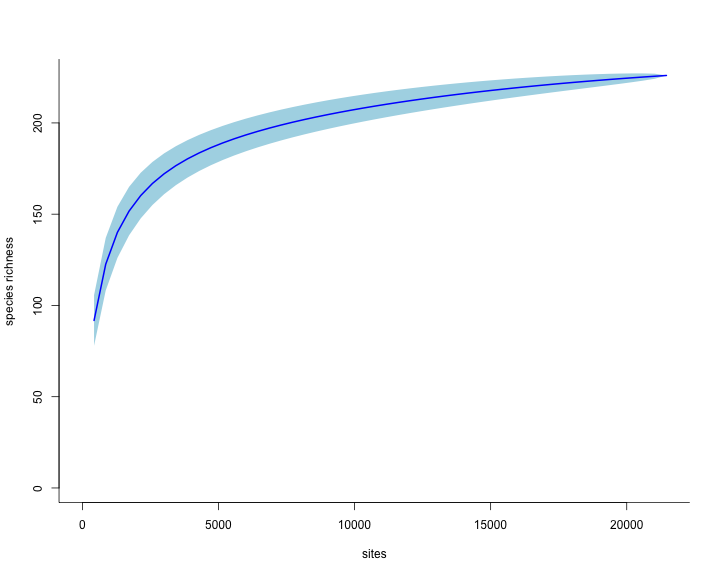

```r
accumplot(Accum.1, ci.type = "poly", col = "blue", lwd = 2, ci.lty = 0, ci.col = "lightblue",
    type = "n")  # With CI intervals
```

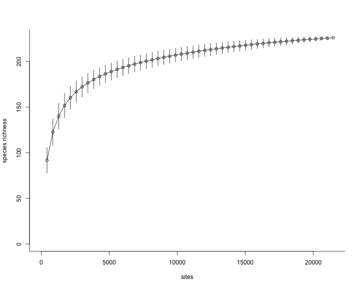

```r
accumplot(Accum.1)  # Simple plot
```

### Asymptotic estimators

```r
specpool(BCI)
```

```
##     Species  chao chao.se jack1 jack1.se jack2  boot boot.se  n
## All     226 237.6   6.659 246.6    5.651 248.9 236.7   3.469 50
```

Function `specpool` uses a collection of sites (i.e., plots or subplots); but there are methods to estimate the number of “unseen” species in a single site. These functions require the count of individuals.

Just do:

```r
estimateR(BCI[k, ])  # Not run
```

```
## Error: objeto 'k' no encontrado
```

where \(k\) is any of the 1 ha plots in the BCI dataset. Chao, ACE, etc., are non-parametric estimators of species richness.

```r
estimateR(BCI[12, ])  # For subplot no. 12
```

```
##               12
## S.obs     85.000
## S.chao1  111.714
## se.chao1  12.997
## S.ACE    129.001
## se.ACE     6.843
```

See the application to other examples (population genetics, complex networks, etc.) in the pdf files of the presentations.